# Lecture 07: Flow control

## 0.1.0 A quick Introduction to R for Data Science

This "Introduction to R for Data Science" is brought to you by the Centre for the Analysis of Genome Evolution & Function's (CAGEF) bioinformatics training initiative. This CSB1020 was developed based on feedback on the needs and interests of the Department of Cell & Systems Biology and the Department of Ecology and Evolutionary Biology.

This lesson is the last in a 7-part series. The idea is that at the end of the series, you will be able to import and manipulate your data, make exploratory plots, perform some basic statistical tests, test a regression model, and make some even prettier plots and documents to share your results.

The structure of the class is a code-along style: It is fully hands on. Prior to each lecture, the materials will be available for download at [QUERCUS](https://q.utoronto.ca), so you can spend more time coding than taking notes.

## 0.1.1 Class objectives

At the end of this session you will be able to write loops to address flow control

1. Control flow
2. Combining control flow with useful functions
3. Build your own function in R

## 0.3.0 A legend for text format in Jupyter markdown

`grey background` - a package, function, code, command or directory. Backticks are also use for in-line code.  
*italics* - an important term or concept or an individual file or folder  
**bold** - heading or a term that is being defined  
blue text - named or unnamed hyperlink

## 0.4.0 Data used in this session

## 0.4.1 Dataset 1: compounds_stats.csv

We'll be working with this dataset to help us work through the different aspects of control flow.

## 0.4.2 Source file: lecture07.R

We'll be using this source file later to show how you can save your own functions and import them for data analysis.

## 0.5.0 Packages Used in This Lesson

`ggplot2`

`dplyr`

`viridis`

Please install and load these packages for the lesson. You can actually just load the `tidyverse` library for simplicity.

```r
# Just load the tidyverse since it contains both dplyr and ggplot2
library(tidyverse)
library(viridis)
```

## 1.0.0 Control flow moves you beyond linear programming

Although we have only briefly touched on some of the aspects regarding control flow, it has been implemented behind the scenes in many of the functions you've used throughout this course. From your experience in Jupyter Notebooks, the order in which a code cell's individual statements or instructions are executed can be considered part of control flow. Expanding, when you see the number order of the code cells, this also indicates the control flow of the entire notebook or program. Once a code cell is run, the objects it has generated remain stored in memory and available for access.

Within our code cells and overall program, control flow can involve statements that help to generate choice loops, conditional statements, and move throughout the program. These specific statements allow us to run different blocks of code at different times. This can be accomplished through

- for loops
- cycling through values
- if statements
- while and repeat loops
- next and break

In this lecture, we'll touch on all of these concepts to give you a taste of how you can make your programs accomplish more with less actual code. Let's start by loading up an example dataset to play around with.

```r
# set working directory
getwd()

# read our file in with read.csv()
compounds_data <- read.csv("./data/compounds_stats.csv", header = TRUE,
                           stringsAsFactors = FALSE, check.names = FALSE)

# explore our loaded data frame
head(compounds_data)
```

'C:/Users/mokca/Dropbox/!CAGEF/Course_Materials/Introduction_to_R/2021.01_Intro_to_R/lecture_7_flow_control'

A data.frame: 6 × 6

|  | compound <chr> | salinity <chr> | group <chr> | day <int> | mean_methane <dbl> | sd_methane <dbl> |
| --- | --- | --- | --- | --- | --- | --- |
| 1 | substrate_free | brackish | media_only | 1 | 0 | 0 |
| 2 | substrate_free | fresh | media_only | 1 | 0 | 0 |
| 3 | substrate_free | saline | media_only | 1 | 0 | 0 |
| 4 | benzene | brackish | sterile | 1 | 0 | 0 |
| 5 | hexane | brackish | sterile | 1 | 0 | 0 |
| 6 | toluene | brackish | sterile | 1 | 0 | 0 |

## 1.1.0 Use `for` loops to repeat commands for a maximum number of iterations

R doesn't care if you write the same code 1000 times or have the interpreter repeat a single copy 1000 times. However, the second is a lot easier for you. The `for` loop helps to reduce code replication by compartmentalizing a set of instructions to repeat instead of copying and pasting the same code several times.

More specifically, a `for` loop executes a statement repetitively until a well-defined endpoint. In this case, it determines when a specific variable's value is no longer contained in a given sequence.

For example, let's say that we want to add `a + 2` 10 times and overwrite it everytime:

```r
# Increment a by 2, the bad way...
a <- 2
a <- a + 2
a <- a + 2
a <- a + 2
a <- a + 2
a <- a + 2
a <- a + 2
a <- a + 2
a <- a + 2
a <- a + 2
a <- a + 2
a
```

22

Sure, 10 times is doable by hand, just copy-paste. But what if you need to perform that same task, say 1,000 times? What if the code was more complex than `a <- 2`? That is when `for` loops come to the rescue.

```r
# Increment 'anything' using a for loop
anything = 10

# Set up your for loop with a 'tally' count
for (tally in 1:1000) {
  anything <- anything + 2
}

tally
anything
```

1000

2010

## 1.1.1 The `for` loop can be described in three stages

1. `for(x in y)`: Set a variable to equal the next value in a sequence
2. `{ code to run }` Run a set of code with that variable at that value
3. Repeat (hence the loop)

There are a number of ways to set the counting variable within the `for()` initialization. In reality, you just need to supply a vector of elements for it to iterate through. This could be a sequence where `y` is defined as `a:b`, or a numeric vector, or even a vector of objects! Each of these is assigned to `x` in our loop and must be used appropriately.

Note that without `{...}` enclosing your code, R will run *only* the first statement right after the `for()` call. This can exist on the same line, or on the next line. Subsequent lines, regardless of indentation, will not be run as part of the loop. This behaviour lets you quickly build a simple `for()` loop or you can extend the behaviour to accomplish many or more complex tasks.

Let's take a look at the `seq()` function and how you can use it within a `for()` loop.

```r
# Use the seq() function
seq(from = 1, to = 10, by = 0.5)

# let's use seq() in a for loop to count, no braces but indentation
for(variable in seq(1, 10, 0.5))
    print(variable)
    print("middle but not really")
print("This is the end")
```

1. 1

2. 1.5

3. 2

4. 2.5

5. 3

6. 3.5

7. 4

8. 4.5

9. 5

10. 5.5

11. 6

12. 6.5

13. 7

14. 7.5

15. 8

16. 8.5

17. 9

18. 9.5

19. 10

```
[1] 1
[1] 1.5
[1] 2
[1] 2.5
[1] 3
[1] 3.5
[1] 4
[1] 4.5
[1] 5
[1] 5.5
[1] 6
[1] 6.5
[1] 7
[1] 7.5
[1] 8
[1] 8.5
[1] 9
[1] 9.5
[1] 10
[1] "middle but not really"
[1] "This is the end"
```

```r
# for loop on a single line
for(variable in seq(1, 10, 0.5)) print(variable); print("This is the end")
```

```
[1] 1
[1] 1.5
[1] 2
[1] 2.5
[1] 3
[1] 3.5
[1] 4
[1] 4.5
[1] 5
[1] 5.5
[1] 6
[1] 6.5
[1] 7
[1] 7.5
[1] 8
[1] 8.5
[1] 9
[1] 9.5
[1] 10
[1] "This is the end"
```

```r
# for loop on a single line, with brackets
for(variable in seq(1, 10, 0.5)) {print(variable); print("middle")}; print("This is the end")
```

```
[1] 1
[1] "middle"
[1] 1.5
[1] "middle"
[1] 2
[1] "middle"
[1] 2.5
[1] "middle"
[1] 3
[1] "middle"
[1] 3.5
[1] "middle"
[1] 4
[1] "middle"
[1] 4.5
```

[output cut: 24 more lines]

## 1.1.2 Common functions are just pre-programmed `for()` loops

As was mentioned at the start of this section, under the hood, many of the functions that we commonly use are just `for()` loops. We can easily replicate them with explicit for loops but it takes up extra coding time! For example, we can replicate the `rep()` function.

```r
# Use the rep() function to print the number 1-5, 8 times
rep(x = 1:5, times=8)

# # for loop version variables need to be set
rm(seq)

x <- 1:5
n <- 8
seq <- NULL

# Build our for loop
for (i in 1:(n-1)){
    seq <- c(seq, x)
    print(seq)
  }

seq
i
```

1. 1

2. 2

3. 3

4. 4

5. 5

6. 1

7. 2

8. 3

9. 4

10. 5

11. 1

12. 2

13. 3

14. 4

15. 5

16. 1

17. 2

18. 3

19. 4

20. 5

21. 1

22. 2

23. 3

24. 4

25. 5

26. 1

27. 2

28. 3

29. 4

30. 5

31. 1

32. 2

33. 3

34. 4

35. 5

36. 1

37. 2

38. 3

39. 4

40. 5

```
[1] 1 2 3 4 5
 [1] 1 2 3 4 5 1 2 3 4 5
 [1] 1 2 3 4 5 1 2 3 4 5 1 2 3 4 5
 [1] 1 2 3 4 5 1 2 3 4 5 1 2 3 4 5 1 2 3 4 5
 [1] 1 2 3 4 5 1 2 3 4 5 1 2 3 4 5 1 2 3 4 5 1 2 3 4 5
 [1] 1 2 3 4 5 1 2 3 4 5 1 2 3 4 5 1 2 3 4 5 1 2 3 4 5 1 2 3 4 5
 [1] 1 2 3 4 5 1 2 3 4 5 1 2 3 4 5 1 2 3 4 5 1 2 3 4 5 1 2 3 4 5 1 2 3 4 5
```

1. 1

2. 2

3. 3

4. 4

5. 5

6. 1

7. 2

8. 3

9. 4

10. 5

11. 1

12. 2

13. 3

14. 4

15. 5

16. 1

17. 2

18. 3

19. 4

20. 5

21. 1

22. 2

23. 3

24. 4

25. 5

26. 1

27. 2

28. 3

29. 4

30. 5

31. 1

32. 2

33. 3

34. 4

35. 5

7

## 1.1.3 Self-referencing variables must be declared outside your loops

If you declared `seq <- NULL` or `seq <- x` within the loop, it would repeat this command with every iteration, thus overwriting it back to a native state with each loop. Nothing would progress! We'll use this concept to springboard us into the idea of scope.

## 1.1.4 The scope (persistence) of variables is tied to when/where they are declared

Control flow statements as with other compartmentalized sections of code can be thought of as separate rooms in a house or sandboxes in a playground.

- The main program/script is somewhat like a person in the house that is navigating from room to room based on a set of instructions.
- When the program first enters the house, it is given a (Global) notepad to take notes (like variables)
- When a progam wanders into a new room (ie a function) it is provided a new (local) notepad to write about any *new* variables it encounters. If it sees anything in this new room that pertains to outside area, it will write it down on the Global notepad.
- When it leaves a room, it must leave behind the local notepad.

Thus a variable is either global or local in scope. If it is local, then the information about it simply disappears at the end of the function or control flow. The scope of a variable can usually be considered as between the `{...}` of a programming section. After you've left that section, anything explicitly declared within (ie new variables from that section) will be released from memory. Of course, R doesn't exactly play by those rules, and stray variables can float in memory. If you want to ensure that variables from something like a for loop remain local, you can use the `local()` command or create a `function()`.

**Why is scope important?**

Understanding this concept will save you a lot of troubles down the road as you make more and more complex programs. You'll learn to avoid declaring variables in the wrong place, or trying to access ones that no longer exist in your scope. Let's revisit our example from above.

```r
# for loop version variables need to be set
rm(seq, j)
x <- 1:5
n <- 8
seq <- NULL

# Build a local for loop
local(
    for (i in 1:n){
        seq <- c(seq, x)
        print(seq)
        j = seq # assign a value to j
    }
)

seq
i
```

```
[1] 1 2 3 4 5
 [1] 1 2 3 4 5 1 2 3 4 5
 [1] 1 2 3 4 5 1 2 3 4 5 1 2 3 4 5
 [1] 1 2 3 4 5 1 2 3 4 5 1 2 3 4 5 1 2 3 4 5
 [1] 1 2 3 4 5 1 2 3 4 5 1 2 3 4 5 1 2 3 4 5 1 2 3 4 5
 [1] 1 2 3 4 5 1 2 3 4 5 1 2 3 4 5 1 2 3 4 5 1 2 3 4 5 1 2 3 4 5
 [1] 1 2 3 4 5 1 2 3 4 5 1 2 3 4 5 1 2 3 4 5 1 2 3 4 5 1 2 3 4 5 1 2 3 4 5
 [1] 1 2 3 4 5 1 2 3 4 5 1 2 3 4 5 1 2 3 4 5 1 2 3 4 5 1 2 3 4 5 1 2 3 4 5 1 2 3
[39] 4 5
```

7

## 1.1.5 Cycle through values using a `for()` loop

The most useful thing to do with a for loop is to cycle through values. Let's plot methane per day of each individual row using base R's plotting functions (instead of ggplot).

```r
# Pull down the structure and colnames of our compounds_data
str(compounds_data)
colnames(compounds_data)
```

```
'data.frame':	480 obs. of  6 variables:
 $ compound    : chr  "substrate_free" "substrate_free" "substrate_free" "benzene" ...
 $ salinity    : chr  "brackish" "fresh" "saline" "brackish" ...
 $ group       : chr  "media_only" "media_only" "media_only" "sterile" ...
 $ day         : int  1 1 1 1 1 1 1 1 1 1 ...
 $ mean_methane: num  0 0 0 0 0 0 0 0 0 0 ...
 $ sd_methane  : num  0 0 0 0 0 0 0 0 0 0 ...
```

1. 'compound'

2. 'salinity'

3. 'group'

4. 'day'

5. 'mean_methane'

6. 'sd_methane'

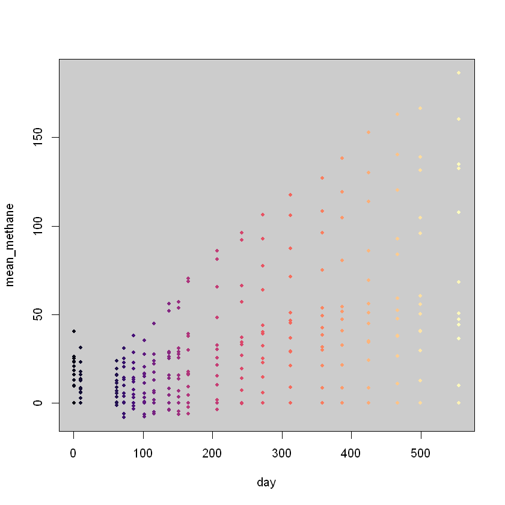

```r
#declare empty plot (canvas)
plot(mean_methane ~ day, data = compounds_data, col = 0)
rect(par("usr")[1],par("usr")[3],par("usr")[2],par("usr")[4],col = "gray80")

# we can use the variable to select different data each time
for(i in 1:nrow(compounds_data)) {
    points(mean_methane ~ day,
        data = compounds_data[i, ],
        col = magma(nrow(compounds_data))[i],
        pch=20)
}
```

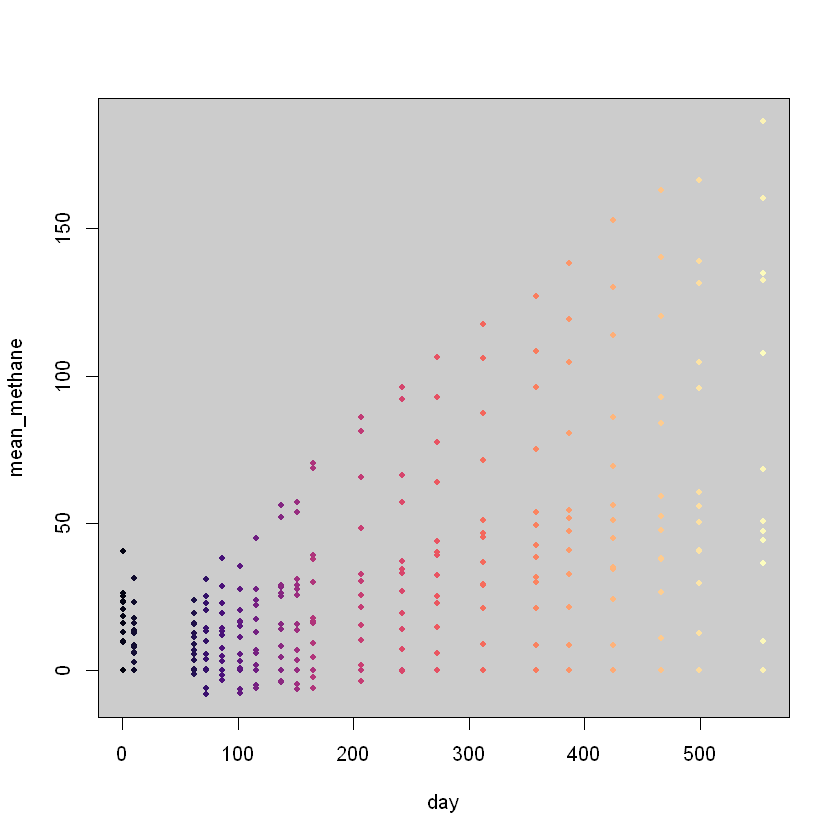

```r
# another way
#declare empty plot (canvas)
plot(mean_methane ~ day, data = compounds_data, col = 0)
rect(par("usr")[1],par("usr")[3],par("usr")[2],par("usr")[4],col = "gray80")

# Set up our for loop based on a call to dim()
for(i in 1:dim(compounds_data)[1]) {
    points(mean_methane ~ day,
        data = compounds_data[i, ],
        col = magma(dim(compounds_data)[1])[i],
        pch=20)
}
```

## 1.1.6 Iterating through a vector of elements in a `for()` loop

Another handy feature of the `for()` loop in R is being able to directly give the loop a vector to iterator through until there are no elements left. This will come in handy when applying the same transformations, functions, or calculations on different subsets or elements within a vector.

We'll start with a simple example of looping through a small character vector.

```r
# for loop in a single line, with brackets
for(variable in c("I", "You", "We all")) {
    print(variable)
    print("scream;")
}
print ("for ice cream")
```

```
[1] "I"
[1] "scream;"
[1] "You"
[1] "scream;"
[1] "We all"
[1] "scream;"
[1] "for ice cream"
```

Lets use a `t.test()` to look for methane production differences between the salinity levels of every 10th day (starting at day 2), excluding the "brackish" salinity group.

```r
# subset dataset every day that ends in a 2 and exclude brackish
# %% is a quick math symbol for modulo (return a remainder)

subdata <- compounds_data  %>%
    filter(day %% 10 == 2, salinity != "brackish")


# create an empty data frame to store the output of the for loop
result <- data.frame(day = unique(subdata$day), difference = NA, p_value = NA)
result

# for loop to calculate difference in means between fresh vs saline groups in salinity

for(i in result$day) {
    # Generate a t-test on subset by day
    t <- t.test(mean_methane ~ salinity, subdata[subdata$day == i, ])
    # write the results to our data frame
    result[result$day == i, "difference"] <- diff(t$estimate)
    result[result$day == i, "p_value"] <- t$p.value
}

result
```

A data.frame: 6 × 3

| day <int> | difference <lgl> | p_value <lgl> |
| --- | --- | --- |
| 62 | NA | NA |
| 72 | NA | NA |
| 102 | NA | NA |
| 242 | NA | NA |
| 272 | NA | NA |
| 312 | NA | NA |

A data.frame: 6 × 3

| day <int> | difference <dbl> | p_value <dbl> |
| --- | --- | --- |
| 62 | -6.21250 | 0.07623434 |
| 72 | -10.46250 | 0.03109609 |
| 102 | -10.47292 | 0.03486736 |
| 242 | -12.38958 | 0.19607602 |
| 272 | -11.96667 | 0.27497031 |
| 312 | -11.26875 | 0.36781942 |

## 1.1.7 Application of for loops through replication of `tapply()`

Let's replicate the `tapply()` function although don't need it to have the same formatting. `tapply()` applies "a function to each cell of a ragged array, that is to each (non-empty) group of values given by a unique combination of the levels of certain factors". We'll use it on our dataset `compounds_data` and save the result in `compound_mean`.

```r
# take alook at the apply family of functions R
?tapply
head(compounds_data)
```

A data.frame: 6 × 6

|  | compound <chr> | salinity <chr> | group <chr> | day <int> | mean_methane <dbl> | sd_methane <dbl> |
| --- | --- | --- | --- | --- | --- | --- |
| 1 | substrate_free | brackish | media_only | 1 | 0 | 0 |
| 2 | substrate_free | fresh | media_only | 1 | 0 | 0 |
| 3 | substrate_free | saline | media_only | 1 | 0 | 0 |
| 4 | benzene | brackish | sterile | 1 | 0 | 0 |
| 5 | hexane | brackish | sterile | 1 | 0 | 0 |
| 6 | toluene | brackish | sterile | 1 | 0 | 0 |

```r
# use tapply to get the mean_methane value when grouping by compound
tapply(compounds_data$mean_methane,
       compounds_data$compound,
       mean,
       na.rm = TRUE)
```

**benzene**

19.5372222222222

**hexane**

22.5370138888889

**substrate_free**

12.7518055555556

**toluene**

21.0144444444444

```r
# mimic tapply using for loop
# First build a data frame to hold our result
# Each row will represent a unique compound
compound_mean <- data.frame( "compound" = unique(compounds_data$compound),
                             "mean_methane" = NA)

for(i in 1:nrow(compound_mean)) {
  # iterate through compound names
  curr_compound <- compound_mean[i, 1]  # this could also be written as compound_mean$compound[i]

  # calculate the mean of all samples that share the same compound name.
  compound_mean[i, 2] <- mean(compounds_data[compounds_data$compound == curr_compound, "mean_methane"], na.rm = TRUE)
}

compound_mean
```

A data.frame: 4 × 2

| compound <chr> | mean_methane <dbl> |
| --- | --- |
| substrate_free | 12.75181 |
| benzene | 19.53722 |
| hexane | 22.53701 |
| toluene | 21.01444 |

## 1.2.0 Generate conditional branches using `if()` statements

One of the big advantages of programming is to have conditional statements in your code. R can make binary decisions like "if data meets a condition, do this". Some of these happen implicitly as in a `for()` loop but you can also declare these decision branches explicity.

The `if()` (conditional argument) evaluates statements that are either FALSE or TRUE. The general format is

```
if (boolean expression) {
   // statement(s) will execute if the boolean expression is true.
}
```

```r
# Practice with an if() statement
x <- c("what", "is", "truth")

if("truth" %in% x) {
  print("Truth is found")
}
```

```
[1] "Truth is found"
```

## 1.2.1 More complex conditional branches may require the `else()` statement

Now that we know how to use `if()` statements, what if we want to give a second instruction based on the outcome of the `if()` statement? The `else()` and `else if()` statements exist to extend the conditional branch through additional considerations. In general, the structure looks like this:

```
if(boolean_expression) {
   // statement(s) will execute if the boolean expression is TRUE.
} else if () {
   // statement(s) will execute if the new boolean expression is TRUE.
else {
   // statement(s) will execute if none of the above boolean expressions were TRUE.
}
```

```r
# Practice with a complex if() statement
x <- c("what", "is", "Truth", "TRUTH")

# Build a complex cascade of statements looking for Truth
if("TRUTH" %in% x) {
    print("TRUTH is found")
} else if ("Truth" %in% x) {
    print ("Truth is found")
} else { # notice the placement of else is directly after the closing }
    print ("The truth is out there... somewhere")
}
```

```
[1] "TRUTH is found"
```

## 1.2.2 Use `if()` statements to generate system messages

If/else statements can also be used to perform system-wide tasks, like generating a warning or breaking a code. For example, if we are writing a file to a directory and there is already a file with the same name, we should generate a warning or simply stop. Without the warning, the existing file will be silently overwritten.

```r
# Check if our file exists
# Use dir() to return a vector of file names and then ask if any match ours.
if(sum(dir() == "Methane mean by compound.csv") > 0) {

  print("Stop! A file with that same name already exists")

} else {

    # The file does not exist, print the go-ahead and save the file
    print("No files with the same name. Good to go!")

}

write.csv(x = compound_mean, file = "Methane mean by compound.csv",
              row.names = FALSE, quote = FALSE)
```

```
[1] "Stop! A file with that same name already exists"
```

### 1.2.2.1 Use effective control flow to ensure your intentions are met

Despite the warning in our code, the file in our example would still be overwritten. The call to `write.csv()` is outside the control flow of the conditional if else. To fulfill our true intentions, we should move the placement of the write function so that it is under the direct influence of the control flow.

```r
# Check if our file exists
if(sum(dir() == "Methane mean by compound.csv") > 0) {

  print("Stop! A file with that same name already exists")

} else {

    # The file does not exist, print the go-ahead and save the file
    print("No files with the same name. Good to go!")
    # Write the file as part of the same control statement
    write.csv(x = compound_mean, file = "Methane mean by compound.csv",
              row.names = FALSE, quote = FALSE)
}
```

```
[1] "Stop! A file with that same name already exists"
```

## 1.2.3 The `ifelse()` is an effective control flow statement for simple tasks

Rather than making a large control flow block for simple tasks, we can supplement the `ifelse()` command as a way to contain all of our conditional statements and commands in one function. This is a much more powerful command than it appears to be as you can supply a set of vectors to this function as well!

```
ifelse(boolean_expression_vector, true_outcome_vector, false_outcome_vector)
```

Watch out for vector recycling! It's convenient for re-assigning values across vectors but note that we aren't performing any complex actions or response. Just assigning outcomes/values based on our evaluation expression.

```r
# A simple example of ifelse()
rm(a)

i <- 3

ifelse(test = i < 5, yes = a <- 0, no = a <- 1)

a

# A complex vectorized example of ifelse()
i <- c(1:10)

ifelse(test = i < 5, yes = 0, no = 1) # Can we achieve this in a simpler way?
```

0

0

1. 0

2. 0

3. 0

4. 0

5. 1

6. 1

7. 1

8. 1

9. 1

10. 1

## 1.3.0 Running loops without a predetermined end-point

There may be instances where you need to run loops on data until you find a certain piece of information, or until a specific condition is met rather than examining all of the elements within a set. There are two ways you can accomplish these "open-ended" loops.

## 1.3.1 `while()` loops run conditionally

Unlike using `for()` loops which continue to execute until a specific iteration number, the `while()` loop executes a command as long as a conditional expression continues to evaluate as TRUE at each iteration. This conditional_expression must evaluate as TRUE to begin execution as well. The `while()` loop can be thought of as a special implementation of an `if()` statement that repeats over and over again until the conditional fails.

```r
# Initialize our variable for conditional assessment
x <- 0

# Generate the while loop, incrementing x by 1 on each iteration, as long as x < 10
while(x < 10) {
  x <- x + 1
  print(x)
  }
```

```
[1] 1
[1] 2
[1] 3
[1] 4
[1] 5
[1] 6
[1] 7
[1] 8
[1] 9
[1] 10
```

```r
# Loop will be ignored if the condition is FALSE and nothing gets printed
x <- 20

while(x < 10) {
    x <- x + 1
    print(x)
}
```

### 1.3.1.1 Conditional loops can become endless

When programming a conditional loop you must always include a statement that alters the condition or breaks out of (coming up) the loop itself. It's also important to note the order or placement of when you alter the condition in your loops. All the command statements within the loop, unless otherwise specified, will execute before the re-evaluation of the conditional statement.

For example, a programmer is assigned a task: "While you're at the grocery store, buy some eggs". The programmer never came back home.

```r
# Set your initial value
programmer <- " at the grocery store"

# Build your while loop
while(programmer == " at the grocery store") {
  print("buy some eggs")
  programmer <- "bought some eggs"
}

print(programmer)
# When do we provide the opportunity to change?
```

```
[1] "buy some eggs"
[1] "bought some eggs"
```

## 1.3.2 Using `next` and `break` to exit any kind of looping structure

The explicit use of the `next` and `break` commands will break free from the current looping structure but each differs in what they do afterwards.

- The `next` command will exit the current iteration in the loop structure but will return to run the next iteration.
  - Use this to skip over commands within your loop
- the `break` command will completely exit the loop structure, as if it had reached its natural end.
  - Use this to permanently exit your looping structure

```r
# using next within our for loop
for(i in 1:10) {

    if (i == 5) {
        next # skips the next iteration of the loop
    }
    print(i)
}
i
```

```
[1] 1
[1] 2
[1] 3
[1] 4
[1] 6
[1] 7
[1] 8
[1] 9
[1] 10
```

10

```r
# Using break
for(i in 1:10) {

    if (i == 5) {
        break # completely exits the loop
    }
    print(i)
}
i
```

```
[1] 1
[1] 2
[1] 3
[1] 4
```

5

## 1.3.3 `repeat` loops run endlessly unless specifically interrupted by `break`

Unlike the while loop, which can end through the conditional being met, a `repeat()` loop has no explicit conditional statement built into it's formation. Instead, it will continue to repeat until it is broken out of by the `break` command.

```r
# Using repeat() to endlessly loop

i = 1

repeat  {

    if (i == 20) {
        break # completely exits the loop
    }
    print(i)
    i = i + 1
}
i
```

```
[1] 1
[1] 2
[1] 3
[1] 4
[1] 5
[1] 6
[1] 7
[1] 8
[1] 9
[1] 10
[1] 11
[1] 12
[1] 13
[1] 14
[1] 15
[1] 16
[1] 17
[1] 18
[1] 19
```

20

## 1.3.4 Be mindful of how you iterate through your loops

Depending on the *order* in which you set up your conditionals, you may accidentally produce unexpected issues. It is best to consider the order in which you want to accomplish tasks within your loops before beginning the next iteration. This is especially relevant in the case of a conditional loop (`while()` or `repeat`) where you must include a variable that can eventually meet the conditions for exit.

```r
# Using repeat() to demonstrate that conditional placement matters.
i = 1

# What numbers will this code print?
# What happens if we move the print command around?
repeat  {

    i = i + 1
    if (i == 20) {
        break # completely exits the loop
    }
    print(i)
}
```

```
[1] 2
[1] 3
[1] 4
[1] 5
[1] 6
[1] 7
[1] 8
[1] 9
[1] 10
[1] 11
[1] 12
[1] 13
[1] 14
[1] 15
[1] 16
[1] 17
[1] 18
[1] 19
```

### 1.3.4.1 Use loops to simplify your code, but don't re-invent the wheel!

Depending on task you working on, perhaps there is already a function that satisfies your need so you don't have to use explicit `for()` loops. Make use of existing functions whenever you can because those have already been optimized to be fast and efficient.

Taking advantage of functions can allow you to keep your code clean rather than programming for loops to generate a simple number pattern.

## 2.0.0 Increasing our complexity by combining `for()` loops with `ggplot()`

Let's say, we are not ready to start making some plots for our manuscript, and we want to make individual plots for each salinity. The code below makes one plot for each salintiy level, i.e. brackish, fresh, or saline, depending on what salinity you pass on to the code.

```r
library(repr)

# Note that the standard display size is a 7x7 inch space. let's double the width
options(repr.plot.width=21, repr.plot.height=7)
```

```r
# An alternate way to create a new column in your data frame
# compounds_data$unique_identifier <- paste(compounds_data$salinity,
#                                          compounds_data$compound,
#                                          compounds_data$group,
#                                          sep = "_")

# Use dplyr to help you do it instead! The code is slightly simpler
compounds_data <- compounds_data %>%
   mutate(unique_identifier = paste(salinity, compound, group, sep="_"))

head(compounds_data)
```

A data.frame: 6 × 7

|  | compound <chr> | salinity <chr> | group <chr> | day <int> | mean_methane <dbl> | sd_methane <dbl> | unique_identifier <chr> |
| --- | --- | --- | --- | --- | --- | --- | --- |
| 1 | substrate_free | brackish | media_only | 1 | 0 | 0 | brackish_substrate_free_media_only |
| 2 | substrate_free | fresh | media_only | 1 | 0 | 0 | fresh_substrate_free_media_only |
| 3 | substrate_free | saline | media_only | 1 | 0 | 0 | saline_substrate_free_media_only |
| 4 | benzene | brackish | sterile | 1 | 0 | 0 | brackish_benzene_sterile |
| 5 | hexane | brackish | sterile | 1 | 0 | 0 | brackish_hexane_sterile |
| 6 | toluene | brackish | sterile | 1 | 0 | 0 | brackish_toluene_sterile |

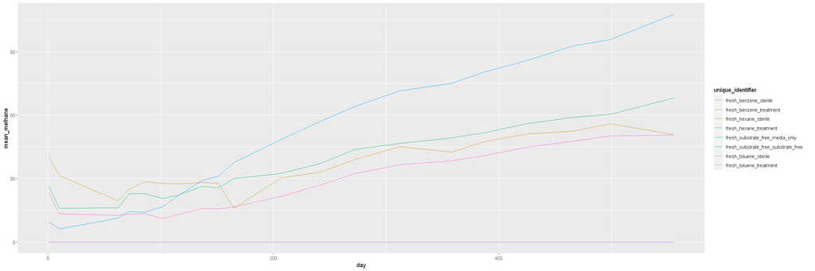

```r
# we want one plot per salinity
ggplot(compounds_data[compounds_data$salinity == "fresh", ]) +
    aes(x=day, y= mean_methane) +
    geom_line(aes(color = unique_identifier))
```

But what if I were to have, say, 25 salinity levels? In this case, a for loop will be the way to go. Take a look at the following code:

```
Saving 33.9 x 33.9 cm image

Saving 33.9 x 33.9 cm image
```

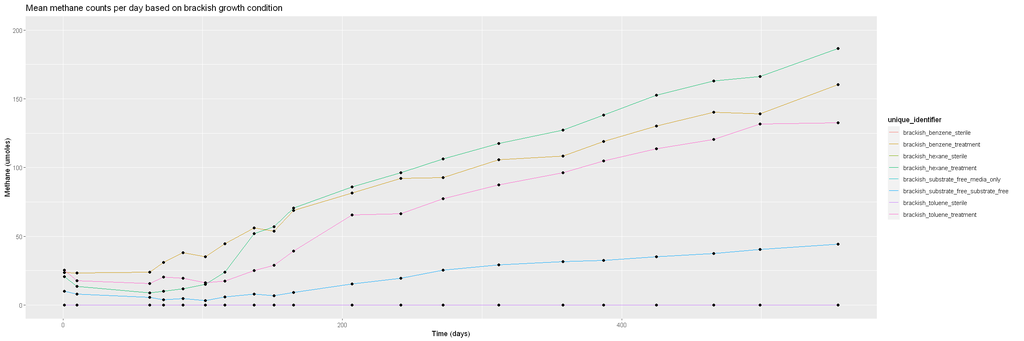

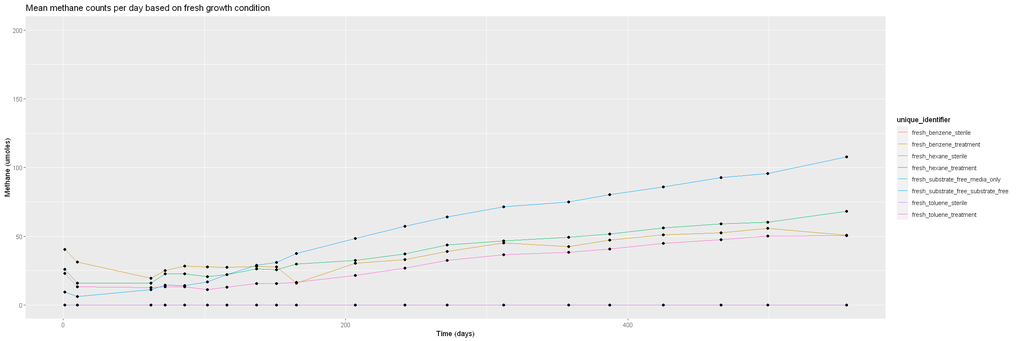

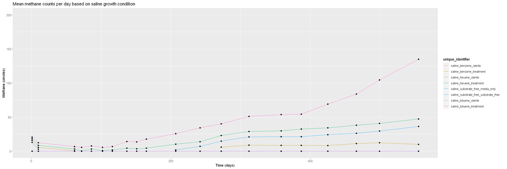

```r
# instead of repeating that code three times, once for each salinity,
# we can just use a for loop that generates and writes one plot per salinity

for (i in unique(compounds_data$salinity)){

    salinity_plot <- ggplot(compounds_data[compounds_data$salinity == i, ]) +
        aes(x = day, y = mean_methane) +
        geom_line(aes(color = unique_identifier)) +
        theme_grey() +
        geom_point() + #aes(shape = replicate), size = 2) +
        scale_y_continuous("Methane (umoles)", limits=c(0, 200)) +
        scale_x_continuous("Time (days)") +

        ggtitle(paste("Mean methane counts per day based on ", i,   " growth condition" , sep='')) # plot title

    print(salinity_plot) # The only way to see the plot is to print it within a for loop

    # Save each plot as it's generated
    ggsave(plot = salinity_plot, filename = paste(i, "graph.png", sep = "_"), path = "data/" ,
           scale=2, device = "png", units = c("cm"))
}
```

## 2.1.0 Take advantage of for loop variables to customize output in each loop

From above you can see that we can take advantage of our incrementing variables within the for loop. We can use it to help subset data, generate titles, and file names. You can use it in combination with other control statements to update the image as well! Just remember to avoid generating errors within your for loop when access or altering data. Ensure you aren't trying to reference or alter data or subsets that do not exist due to missing information in your original datasets.

What if I want one plot for each compound and its sterile control in one page by salinity?

```
Saving 33.9 x 33.9 cm image

Saving 33.9 x 33.9 cm image

Saving 33.9 x 33.9 cm image

Warning message:
"Removed 17 rows containing missing values (geom_point)."
```

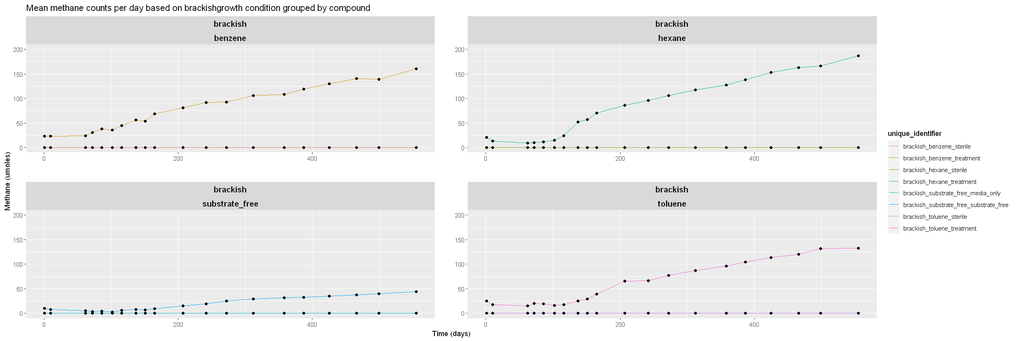

```r
# instead of repeating that code three times, once for each salinity, we can just use a for loop that generates and writes one plot per salinity

for (i in unique(compounds_data$salinity)){

    salinity_plot <- ggplot(compounds_data[compounds_data$salinity == i, ]) +
        aes(x = day, y = mean_methane) +
        geom_line(aes(color = unique_identifier)) +
        theme_grey() + # adds a grey theme to the plots
        theme(panel.spacing = unit(2, "lines")) +
        geom_point() +

        facet_wrap( ~ salinity + compound, ncol=2, nrow = 4, scales = 'free') + # how many rows and columns for facet

        theme(strip.text = element_text(size=12, face="bold")) + #controls facet_wrap's title
        scale_y_continuous("Methane (umoles)", limits=c(0, 200)) + # y axis lable and limits
        scale_x_continuous("Time (days)") + # x axis label
        ggtitle(paste("Mean methane counts per day based on ", i, "growth condition grouped by compound", sep="")) # plot title

    # Only print the brackish dataset
    if (i == "brackish") {
        print(salinity_plot) # The only way to see the plot is to print it within a for loop
    }

    # Save all of the data regardless of set
    ggsave(plot = salinity_plot, filename = paste(i, "graph.facet.png", sep = "_"), path = "data/" ,
           scale=2, device = "png", units = c("cm"))

}
```

## 3.0.0 Can we jump around our code to perform different tasks?

Yes! So far we've covered many ways of control flow but all of our programs have been moving in a linear direction from start to end. That is also just a consequence of working with a Jupyter notebook. Programs, however, are not necessarily run in a linear fashion.

What if you need to perform a set of similar instructions multiple times, at multiple points within your control flow? Perhaps it's even the same kind of `for()` loop on different sets of data? There are a lot of tricks like nested loops but you're better off knowing how to make functions that can be used in other code as well!

The general structure of a script or program can be divided into

1. Global/environmental variables and declarations
   - Describe your script and assumptions
   - Import your libraries
   - Declare any global variables
1. Main program
   - The place where the main statements are occur.
   - It may also be a function call with specific arguments like the location of data files
   - Reading through your annotation, someone else should be able to discern what your program is doing
1. Helper functions or subroutines
   - Here you can create functions or "mini" programs that do work for you.
   - They can be called from anywhere within the program (once loaded into memory)
   - Repetitive tasks whose output only vary based on the input provided
   - Subroutines may work together or call on each other to accomplish a greater task
   - Functions that you use often can be placed into their own files for importing like a package.

## 3.1.0 Declare your own functions with `function()`

In R, a function is declared with the following syntax:

```
function_name = function(parameter1_name, parameter2_name, ... parameter2_name = preset_value) {
    # The specific code of your function goes within the {...}

    return(output)
}
```

Let's convert our plotting code from above into a simple function!

```r
# Input:
# data.df: a data frame at least with the following column names
# $salinity, $mean_methane, $unique_identifier, $compound
# salinity.val: a character/string used to subset data.df based filtering the $salinity column
# Output: make.facet.plot will generate a facet plot from data.df based on the salinity.val
# The plot will be saved to a file ending in "graph.facet.function.png"

make.facet.plot = function(data.df, salinity.val) {

    # Make the plot

    salinity_plot <- ggplot(data.df[data.df$salinity == salinity.val, ]) +
        aes(x = day, y = mean_methane) +
        geom_line(aes(color = unique_identifier)) +
        theme_grey() + # adds a grey theme to the plots
        theme(panel.spacing = unit(2, "lines")) +
        geom_point() +
        facet_wrap( ~  salinity + compound, ncol=2, nrow = 4, scales = 'free') + # how many rows and columns for facet
        theme(strip.text = element_text(size=12, face="bold")) + #controls facet_wrap's title
        scale_y_continuous("Methane (umoles)", limits=c(0, 200)) + # y axis lable and limits
        scale_x_continuous("Time (days)") + # x axis label
        ggtitle(paste("Mean methane counts per day based on ", salinity.val,
                      " growth condition grouped by compound" , sep='')) # plot title

    # print the plot
    print(salinity_plot) # The only way to see the plot is to print it within a for loop

    # save the plot
    ggsave(plot = salinity_plot, filename = paste(salinity.val, "graph.facet.function.png", sep = "_"), path = "data/" ,
         scale=2, device = "png", units = c("cm"))
}
```

### 3.1.0.1 Once your declared functions are stored in memory, they can be called from anywhere.

Now that our subroutine is stored in memory, it can be called as we want! Maybe for different data sets as long as it meets the requirements set out in our description of the function itself. You can even build upon it to use control flow to decide if it will be faceted or not. The code between the two versions is so similar, you could break it into an if statement.

Let's try to use it right now.

```
Saving 33.9 x 33.9 cm image

Saving 33.9 x 33.9 cm image
```

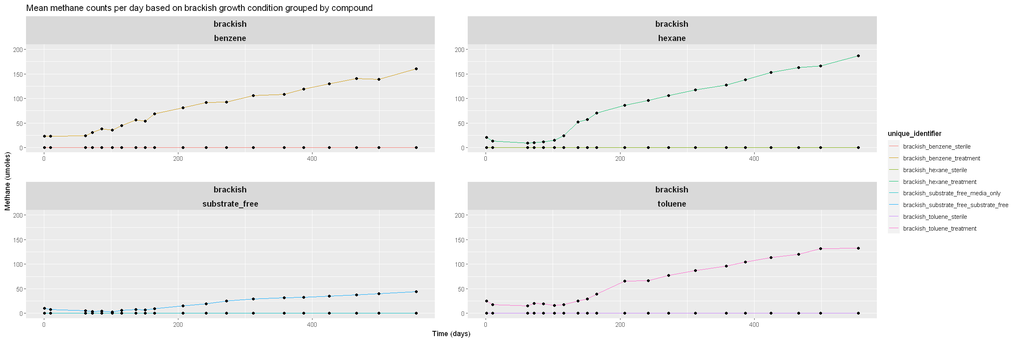

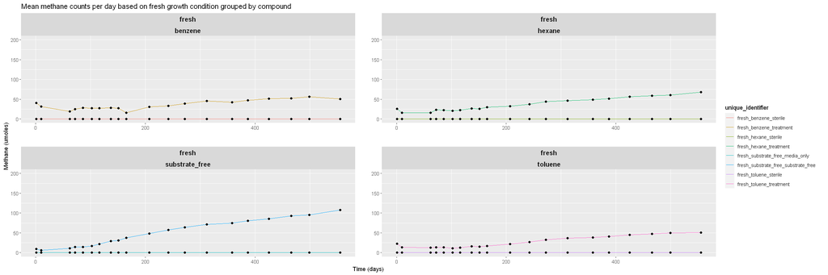

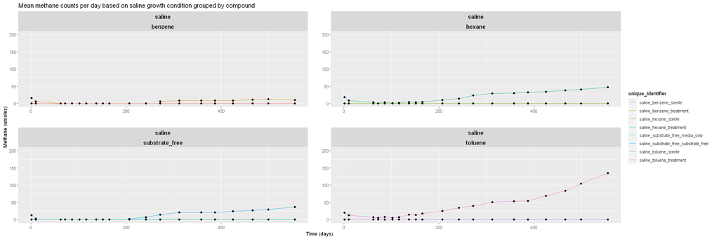

```r
# Call on our function now
for (i in unique(compounds_data$salinity)){

    make.facet.plot(compounds_data, i)
}
```

## 3.2.0 Retrieve data from your function using the `return()` command

Some of your functions may generate subsets of data or results that you would like to further investigate for analysis. For example, when we generate our plots, perhaps we would like to also retrieve information like where the file was saved, along with the subset of data for each.

Using the `return()` command has two consequences:

1. It will terminate or exit the function currently running once this command is called.
2. It will return a single object that will be assigned to a variable or be displayed to the console if unassigned

A special note about the returned object. This can be any kind of object and if you want to return *multiple* objects, put them in a `list()`! Let's update our function

```r
# Input:
# data.df: a data frame at least with the following column names
# $salinity, $mean_methane, $unique_identifier, $compound
# salinity.val: a character/string used to subset data.df based filtering the $salinity column
# Output: make.facet.plot will generate a facet plot from data.df based on the salinity.val
# The plot will be saved to a file ending in "graph.facet.function.png"
# It will return
# [1] subset data
# [2] ggplot object
# [3] save plot filename

save.facet.plot = function(data.df, salinity.val) {

    # Make the data subset
    salinity.data <- data.df  %>% filter(salinity == salinity.val)

    # Make the salinity plot
    salinity_plot <- ggplot(salinity.data) +
        aes(x = day, y = mean_methane) +
        geom_line(aes(color = unique_identifier)) +
        theme_grey() + # adds a grey theme to the plots
        theme(panel.spacing = unit(2, "lines")) +
        geom_point() +
        facet_wrap( ~  salinity + compound, ncol=2, nrow = 4, scales = 'free') + # how many rows and columns for facet
        theme(strip.text = element_text(size=12, face="bold")) + #controls facet_wrap's title
        scale_y_continuous("Methane (umoles)", limits=c(0, 200)) + # y axis lable and limits
        scale_x_continuous("Time (days)") + # x axis label
        ggtitle(paste("Mean methane counts per day based on ", salinity.val,
                      " growth condition grouped by compound" , sep='')) # plot title

    # print the plot
    # print(salinity_plot) # The only way to see the plot is to print it within a for loop

    # generate a save file name
    save.file = paste(salinity.val, "graph.facet.function.png", sep = "_")

    # save the plot
    ggsave(plot = salinity_plot, filename = save.file, path = "data/" ,
         scale=2, device = "png", units = c("cm"))

    #return the file name and data subset
    return(list(salinity.data, salinity_plot, save.file))
}
```

```r
# Call on save.facet.plot function now

brackish.plot <- save.facet.plot(compounds_data, "brackish")

# Look at the data
head(brackish.plot[[1]])

# Display the plot to output
#brackish.plot[[2]]

# What's the file name?
brackish.plot[[3]]
```

```
Saving 33.9 x 33.9 cm image
```

A data.frame: 6 × 7

|  | compound <chr> | salinity <chr> | group <chr> | day <int> | mean_methane <dbl> | sd_methane <dbl> | unique_identifier <chr> |
| --- | --- | --- | --- | --- | --- | --- | --- |
| 1 | substrate_free | brackish | media_only | 1 | 0.00000 | 0.000000 | brackish_substrate_free_media_only |
| 2 | benzene | brackish | sterile | 1 | 0.00000 | 0.000000 | brackish_benzene_sterile |
| 3 | hexane | brackish | sterile | 1 | 0.00000 | 0.000000 | brackish_hexane_sterile |
| 4 | toluene | brackish | sterile | 1 | 0.00000 | 0.000000 | brackish_toluene_sterile |
| 5 | benzene | brackish | treatment | 1 | 23.60000 | 8.006872 | brackish_benzene_treatment |
| 6 | hexane | brackish | treatment | 1 | 20.66667 | 1.450287 | brackish_hexane_treatment |

'brackish_graph.facet.function.png'

## 3.2.0.1 You can nest functions within functions

One of the things you can do as your functions and needs become more complex is to nest functions within other functions. We've already applied this when we call `ggplot()` functions within `save.facet.plot()`.